# CyTOF pipeline, multiple files

2023-03-16

[Home](https://tjburns08.github.io/)

The purpose of this document is to process the fcs files for the CyTOF analysis pipeline. The dataset we are importing comes from [Cross et al, Fronteirs in Immunology 2020](https://www.frontiersin.org/articles/10.3389/fimmu.2020.574057/full). The fcs files can be found on Flow Repository [here](http://flowrepository.org/id/FR-FCM-Z2GG). The purpose of this project was, in their words “to investigate the cellular response in peripheral blood following vaccination with either Vi-TT or Vi-PS.”

Let’s see if we can replicate their findings here!

## Load data

First, we load some libraries we will be using.

```r
library(tidyverse)
library(diffcyt)
library(CATALYST)
library(flowCore)
library(SummarizedExperiment)
library(here)
```

Next, we upload our patient metadata, which we will use when we’re distinguishing between control and treatment.

```r
setwd(here::here("data", "metadata"))

# There's a weird file read bug, where I can't read a handful of files
# Read in the metadata
md <- readr::read_csv("experiment_info.csv")
md <- dplyr::filter(md, read_error == FALSE)

# Filter by vaccine
md <- dplyr::filter(md, vaccine == "TT")

# Remove day 28
md <- md[!grepl("Dneg28", md$day),]

# Set day as group_id
names(md)[which(names(md) == "day")] <- "group_id"

# Set sample ID (for diffcyt)
md$sample_id <- paste0(md$group_id, "_", seq(nrow(md)))
```

The first thing we’re going to do is read in the fcs files of interest as a list of flow frames. If you want a detailed primer of the components of reading in a single, fcs file, please visit my tutorial [here](https://tjburns08.github.io/cytof_pipeline_one_file.html).

```r
setwd(here::here("data", "FlowRepository_FR-FCM-Z2GG_files"))

ff_list <- lapply(md$file_name, function(i) {
    # Get the flow frame object
    ff <- flowCore::read.FCS(i)

    # Random subsample (note how we can treat the flow frame like a dataframe)
    ff <- ff[sample(nrow(ff), 100000),]
    return(ff)
})

names(ff_list) <- md$file_name

ff_list[1:3]
```

```
## $`Plate10_8602_TT_D0_nTD_Live Intact Singlets.fcs`
## flowFrame object 'Plate10_8602_TT_D0_nTD_Live Intact Singlets.fcs'
## with 100000 cells and 52 observables:
##          name        desc     range  minRange  maxRange
## $P1   Bi209Di  209Bi_CD16      3888         0      3888
## $P2   Ce140Di 140Ce_Beads      6236         0      6236
## $P3    Center      Center      3611         0      3611
## $P4   Dy161Di  161Dy_CD26      2397         0      2397
## $P5   Dy162Di  162Dy_CD8a      1695         0      1695
## ...       ...         ...       ...       ...       ...
## $P48  Yb173Di  173Yb_a4b7       505         0       505
## $P49  Yb174Di  174Yb_PD-1      2698         0      2698
## $P50  Yb176Di   176Yb_CLA      9942         0      9942
## $P51 beadDist    beadDist       237         0       237
## $P52     Time        Time      8557         0      8557
## 498 keywords are stored in the 'description' slot
##
## $`Plate10_8602_TT_Dneg21_nTD_Live Intact Singlets.fcs`
## flowFrame object 'Plate10_8602_TT_Dneg21_nTD_Live Intact Singlets.fcs'
## with 100000 cells and 52 observables:
##          name        desc     range  minRange  maxRange
## $P1   Bi209Di  209Bi_CD16     15162         0     15162
## $P2   Ce140Di 140Ce_Beads      6798         0      6798
## $P3    Center      Center      3371         0      3371
## $P4   Dy161Di  161Dy_CD26      2118         0      2118
## $P5   Dy162Di  162Dy_CD8a      1408         0      1408
## ...       ...         ...       ...       ...       ...
## $P48  Yb173Di  173Yb_a4b7      2126         0      2126
## $P49  Yb174Di  174Yb_PD-1       522         0       522
## $P50  Yb176Di   176Yb_CLA     10401         0     10401
## $P51 beadDist    beadDist       257         0       257
## $P52     Time        Time      8557         0      8557
## 498 keywords are stored in the 'description' slot
##
## $`Plate11_8842_TT_D0_nTD_Live Intact Singlets.fcs`
## flowFrame object 'Plate11_8842_TT_D0_nTD_Live Intact Singlets.fcs'
## with 100000 cells and 52 observables:
##          name        desc     range  minRange  maxRange
## $P1   Bi209Di  209Bi_CD16      1735         0      1735
## $P2   Ce140Di 140Ce_Beads      6656         0      6656
## $P3    Center      Center      6510         0      6510
## $P4   Dy161Di  161Dy_CD26      1944         0      1944
## $P5   Dy162Di  162Dy_CD8a      1651         0      1651
## ...       ...         ...       ...       ...       ...
## $P48  Yb173Di  173Yb_a4b7       210         0       210
## $P49  Yb174Di  174Yb_PD-1       416         0       416
## $P50  Yb176Di   176Yb_CLA      8220         0      8220
## $P51 beadDist    beadDist       231         0       231
## $P52     Time        Time     19777         0     19777
## 496 keywords are stored in the 'description' slot
```

Now we load the marker data.

```r
setwd(here::here("data", "metadata"))
marker_info <- readr::read_csv("markers_edited.csv")
```

Now, we’re going to get our data into diffcyt, which will perform clustering and statistics for us.

```r
d_se <- diffcyt::prepareData(d_input = ff_list, experiment_info = as.data.frame(md), marker_info = as.data.frame(marker_info))
d_se
```

```
## class: SummarizedExperiment
## dim: 2000000 52
## metadata(2): experiment_info n_cells
## assays(1): exprs
## rownames: NULL
## rowData names(9): file_name plate ... sample_id read_error
## colnames(52): 209Bi_CD16 140Ce_Beads ... beadDist Time
## colData names(3): channel_name marker_name marker_class
```

Now we transform the data directly within diffcyt.

```r
d_se <- diffcyt::transformData(d_se, cofactor = 5)
```

## FlowSOM clustering

```r
dplyr::filter(marker_info, marker_class == "type")$marker_name
```

```
##  [1] "209Bi_CD16"   "161Dy_CD26"   "162Dy_CD8a"   "163Dy_CD33"   "164Dy_CD161"
##  [6] "166Er_CCR10"  "167Er_CCR7"   "168Er_CCR9"   "170Er_CD3"    "151Eu_ICOS"
## [11] "153Eu_CD45RA" "155Gd_CD27"   "156Gd_CXCR3"  "158Gd_NKG2A"  "160Gd_CD14"
## [16] "165Ho_CD127"  "113In_CD57"   "115In_HLA-DR" "175Lu_CD62L"  "142Nd_CD19"
## [21] "144Nd_IgG"    "145Nd_CD4"    "146Nd_IgD"    "148Nd_IgA"    "150Nd_CD86"
## [26] "141Pr_CCR6"   "147Sm_CD20"   "149Sm_CD56"   "152Sm_TCRgd"  "154Sm_CD123"
## [31] "159Tb_CD11c"  "169Tm_CD25"   "171Yb_CXCR5"  "172Yb_CD38"   "173Yb_a4b7"
## [36] "174Yb_PD-1"   "176Yb_CLA"
```

```r
# Generate clusters
# note: include random seed for reproducible clustering
d_se <- generateClusters(d_se, seed_clustering = 123,
                         xdim = 10,
                         ydim = 10,
                         meta_clustering = TRUE,
                         meta_k = 30)
```

```
## FlowSOM clustering completed in 93.6 seconds
```

Now let’s find our clusters. It’s in rowData. Look at the end, for cluster_id.

```r
rowData(d_se)
```

```
## DataFrame with 2000000 rows and 10 columns
##                                                  file_name    plate patient_id
##                                                   <factor> <factor>   <factor>
## 1          Plate10_8602_TT_D0_nTD_Live Intact Singlets.fcs  Plate10       8602
## 2          Plate10_8602_TT_D0_nTD_Live Intact Singlets.fcs  Plate10       8602
## 3          Plate10_8602_TT_D0_nTD_Live Intact Singlets.fcs  Plate10       8602
## 4          Plate10_8602_TT_D0_nTD_Live Intact Singlets.fcs  Plate10       8602
## 5          Plate10_8602_TT_D0_nTD_Live Intact Singlets.fcs  Plate10       8602
## ...                                                    ...      ...        ...
## 1999996 Plate19_8016_TT_Dneg21_TD_Live Intact Singlets.fcs  Plate19       8016
## 1999997 Plate19_8016_TT_Dneg21_TD_Live Intact Singlets.fcs  Plate19       8016
## 1999998 Plate19_8016_TT_Dneg21_TD_Live Intact Singlets.fcs  Plate19       8016
## 1999999 Plate19_8016_TT_Dneg21_TD_Live Intact Singlets.fcs  Plate19       8016
## 2000000 Plate19_8016_TT_Dneg21_TD_Live Intact Singlets.fcs  Plate19       8016
##          vaccine group_id diagnosis            gating_status sample_id
```

[output cut: 25 more lines]

Let’s get a feel for the cluster frequency distribution. In the table below, cluster ID is the name and the element is the number of cells in that cluster.

```r
rowData(d_se)$cluster_id %>% table() %>% sort()
```

```
## .
##     26     25     15     18     16     17     22      8      6     10     20
##    483    545    645   1618   2475   3543   4435   5072   6728   6765   8327
##     30     21     23     12     29     24      5     11      3      2     19
##  12746  12959  15831  17106  18711  20847  21026  27985  46604  50508  53413
##      4     13     27      9     14      1     28      7
##  62131  71930 133615 136653 158220 183941 249166 665972
```

## Frequency and expression tables

Now we are going to make our frequency and expression tables for statistics and visualization. Diffcyt has built in functionality for that.

We wills start with the counts table. This is the number of cells per cluster per sampel. The results are a new SummarizedExperiment object, so I have to use the “assay” command within the SummarizedExperiment framework to access it. If you’re confused, don’t worry. It took me a while to figure these things out too.

```r
d_counts <- diffcyt::calcCounts(d_se = d_se)
SummarizedExperiment::assay(d_counts)[1:10, 1:10]
```

```
##     D0_1 Dneg21_2  D0_3 Dneg21_4  D0_5 Dneg21_6  D0_7 Dneg21_8  D0_9 Dneg21_10
## 1   5649     4970 14039    12275 11146    10448  3504      153 16913      8049
## 2    556      518  1006     1217  1622     1902  1034     1649 11474     16897
## 3    553      665  1345     1279  3790     4421  2417    15053  1673      2125
## 4    808     1106  3741     4144  4265     6090  1624     5539  2526      4609
## 5    647      736  2112     2330  1338     1272   864     1709   788      1252
## 6     81      112   166      147   115       99   181      692  1381      2128
## 7  35603    35334 58544    58460 26048    22937 51929     4575 30503     20058
## 8    255      311   316      491   226      136   387      622   402       303
## 9  17171    22413  4238     3315  4554     7168  1837     2462  2876      5235
## 10   152      371   220      727   136      459   139      673   253       454
```

Ok, let’s convert these to frequencies, expressed as a percentage.

```r
# The frequency table itself, embedded within the d_counts SummarizedExperiment
# Note that the metadata stored in the SummarizedExperiment file is the same order
d_freqs <- SummarizedExperiment::assay(d_counts) %>% apply(., 2, function(i) {
    result <- i/sum(i)
    return(result*100)
})

d_freqs[1:10, 1:10]
```

```
##      D0_1 Dneg21_2   D0_3 Dneg21_4   D0_5 Dneg21_6   D0_7 Dneg21_8   D0_9
## 1   5.649    4.970 14.039   12.275 11.146   10.448  3.504    0.153 16.913
## 2   0.556    0.518  1.006    1.217  1.622    1.902  1.034    1.649 11.474
## 3   0.553    0.665  1.345    1.279  3.790    4.421  2.417   15.053  1.673
## 4   0.808    1.106  3.741    4.144  4.265    6.090  1.624    5.539  2.526
## 5   0.647    0.736  2.112    2.330  1.338    1.272  0.864    1.709  0.788
## 6   0.081    0.112  0.166    0.147  0.115    0.099  0.181    0.692  1.381
## 7  35.603   35.334 58.544   58.460 26.048   22.937 51.929    4.575 30.503
## 8   0.255    0.311  0.316    0.491  0.226    0.136  0.387    0.622  0.402
## 9  17.171   22.413  4.238    3.315  4.554    7.168  1.837    2.462  2.876
## 10  0.152    0.371  0.220    0.727  0.136    0.459  0.139    0.673  0.253
##    Dneg21_10
## 1      8.049
## 2     16.897
## 3      2.125
## 4      4.609
## 5      1.252
## 6      2.128
## 7     20.058
## 8      0.303
## 9      5.235
## 10     0.454
```

Great. Now let’s look at marker expression per cluster, so we can know what cluster express what, and therefore annotate the clusters.

```r
# Expression heatmap
cluster_exp <- diffcyt::calcMediansByClusterMarker(d_se) %>%
    SummarizedExperiment::assay()

cluster_exp[1:10, 1:10]
```

```
##     209Bi_CD16 161Dy_CD26 162Dy_CD8a  163Dy_CD33 164Dy_CD161 166Er_CCR10
## 1  0.000000000  2.0019095 4.15476605 0.910982136  0.10411798   0.5199511
## 2  0.000000000  3.3256473 4.42377237 1.292785495  0.38170992   0.3979700
## 3  0.000000000  4.8312968 2.40726768 1.160363023  4.90407103   0.2387892
## 4  0.000000000  3.7931034 0.61819295 0.307317999  2.86130098   0.3719349
## 5  0.000000000  2.6404850 0.28892285 0.155731762  0.09491203   3.7108235
## 6  0.000000000  3.1625637 4.54841904 1.430944189  0.39161757   2.9887567
## 7  0.000000000  2.5568997 0.05990236 0.000000000  0.00000000   0.6595953
## 8  0.000000000  0.7283145 0.18726791 0.101486370  0.00000000   3.9821936
## 9  0.003259083  0.4383010 4.27193467 1.107564449  0.39545932   0.2086278
## 10 0.000000000  0.8451694 0.10623622 0.009005288  0.30220868   0.2964242
##    167Er_CCR7 168Er_CCR9 170Er_CD3 151Eu_ICOS
## 1   4.3500834  1.0895094  5.482523  0.6649630
## 2   2.6257716  0.5559694  5.462091  0.5735902
## 3   0.2606128  0.1977314  5.292297  0.0000000
## 4   1.3036729  0.3650131  5.478719  0.4140406
## 5   2.0676812  0.5496652  5.465105  0.9118880
## 6   1.8342222  0.3974784  5.311720  0.7145737
## 7   4.2665956  1.2041999  5.794522  0.7160587
## 8   1.9397112  0.7536517  5.686233  2.7734407
## 9   0.3116464  0.3895733  5.511712  0.4557229
## 10  1.7309551  0.5513596  5.612568  3.6236814
```

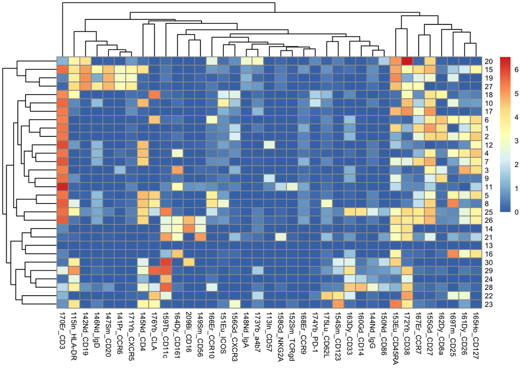

```r
pheatmap::pheatmap(cluster_exp, labels_row = 1:nrow(cluster_exp), fontsize = 7)
```

## Frequency statistics via EdgeR

If this section is too much for the reader (requires working knowledge of supervised learning, and EdgeR’s vocabulary around it), then skip to the next section that has simple statistical tests between conditions.

We’re going to do some statistics on the frequency tables, and then do some visualizations. To do this, we’re going to use EdgeR. This is a linear model framework within Diffcyt. Just think of it as a t-test, but more rigorous.

This is going to seem like a lot, but I’ll go thorugh it slowly. First, you have to make what is called a design matrix. If you want to know what that is with respect to linear models, watch [this video](https://www.youtube.com/watch?v=LoocDAbgwlM).

Design matrices can get complicated, but for this one, we’re just going to compare the two experimental conditions. The design matrix below is robust to multiple conditions in the group_id slot.

```r
design <- model.matrix(~0 + group_id, data = S4Vectors::metadata(d_se)$experiment_info)

# This makes the names acceptable for input into downstream functions by removing
#   "unacceptable" characters. Comes from base R.
colnames(design) <- make.names(colnames(design))
design[1:10,]
```

```
##    group_idD0 group_idDneg21
## 1           1              0
## 2           0              1
## 3           1              0
## 4           0              1
## 5           1              0
## 6           0              1
## 7           1              0
## 8           0              1
## 9           1              0
## 10          0              1
```

From here, we create a contrast matrix. This specifies what comparisons are going to be made. # This contrast matrix is meant for the no-intercept design matrix, where each column is a condition. Every pairwise combo is tested. Note: here, for the contrast matrix to be properly read, we cannot have any whitespace. Explanation for the concept of a contrast matrix can be found [here](https://stats.stackexchange.com/questions/78354/what-is-a-contrast-matrix)

```r
# This names the "Contrasts" column in the contrast matrix
comps <- combn(colnames(design), m = 2) %>% apply(., 2, function(i) paste(i, collapse = "-"))

# comps <- paste("group_idC1D1", colnames(design)[-1]) %>% gsub(" ", "-", .)
contrast <- limma::makeContrasts(contrasts = comps,
                                 levels = design)

contrast
```

```
##                 Contrasts
## Levels           group_idD0-group_idDneg21
##   group_idD0                             1
##   group_idDneg21                        -1
```

Finally, we feed these into the built-in EdgeR statistics, within diffcyt. Note that it outputs another SummarizedExperiment object.

```r
# GLM from EdgeR (options to do other types of modeling here)
res_DA <- diffcyt::testDA_edgeR(d_counts = d_counts, design =  design, contrast = contrast)
res_DA
```

```
## class: SummarizedExperiment
## dim: 30 20
## metadata(0):
## assays(1): counts
## rownames(30): 1 2 ... 29 30
## rowData names(6): cluster_id logFC ... p_val p_adj
## colnames(20): D0_1 Dneg21_2 ... D0_19 Dneg21_20
## colData names(9): file_name plate ... sample_id read_error
```

Rather than tear open the SummarizedExperiment object, we can use a built-in function called topTable to see what is statistically significant and what is not.

```r
# Quick visualization
edger_table <- diffcyt::topTable(res_DA, top_n = nrow(res_DA@elementMetadata)) %>% as_tibble()
edger_table[1:10,]
```

```
## # A tibble: 10 × 3
##    cluster_id      p_val     p_adj
##    <fct>           <dbl>     <dbl>
##  1 20         0.00000138 0.0000414
##  2 13         0.0000395  0.000593
##  3 10         0.000289   0.00289
##  4 15         0.0310     0.233
##  5 3          0.0807     0.371
##  6 4          0.0940     0.371
##  7 23         0.0991     0.371
##  8 26         0.0947     0.371
##  9 22         0.123      0.409
## 10 16         0.208      0.624
```

## Frequency statistics via Mann-Whitney U test

What if you don’t trust the design and contrast matrices above and you need a simple sanify check? What if you don’t want to touch regression-based statistics and you want something simpler? Then you just use a Mann-Whitney U test. I prefer this test in place of a t-test because you don’t have to assume anything about the underlying distributions.

Let’s look again at the freq table and see what info we need.

```r
d_freqs[1:10, 1:10]
```

```
##      D0_1 Dneg21_2   D0_3 Dneg21_4   D0_5 Dneg21_6   D0_7 Dneg21_8   D0_9
## 1   5.649    4.970 14.039   12.275 11.146   10.448  3.504    0.153 16.913
## 2   0.556    0.518  1.006    1.217  1.622    1.902  1.034    1.649 11.474
## 3   0.553    0.665  1.345    1.279  3.790    4.421  2.417   15.053  1.673
## 4   0.808    1.106  3.741    4.144  4.265    6.090  1.624    5.539  2.526
## 5   0.647    0.736  2.112    2.330  1.338    1.272  0.864    1.709  0.788
## 6   0.081    0.112  0.166    0.147  0.115    0.099  0.181    0.692  1.381
## 7  35.603   35.334 58.544   58.460 26.048   22.937 51.929    4.575 30.503
## 8   0.255    0.311  0.316    0.491  0.226    0.136  0.387    0.622  0.402
## 9  17.171   22.413  4.238    3.315  4.554    7.168  1.837    2.462  2.876
## 10  0.152    0.371  0.220    0.727  0.136    0.459  0.139    0.673  0.253
##    Dneg21_10
## 1      8.049
## 2     16.897
## 3      2.125
## 4      4.609
## 5      1.252
## 6      2.128
## 7     20.058
## 8      0.303
## 9      5.235
## 10     0.454
```

Each p-value will come from a test on each cluster. The cluster is the row. The conditions are in the columns, before the underscore. So we have all the information we need. Let’s run the test on the first column, so you can see what’s going on.

Note that the function is called “wilcox.test.” From the descriptin of the function: “Performs one- and two-sample Wilcoxon tests on vectors of data; the latter is also known as ‘Mann-Whitney’ test.”

```r
test <- d_freqs[1,]
test
```

```
##      D0_1  Dneg21_2      D0_3  Dneg21_4      D0_5  Dneg21_6      D0_7  Dneg21_8
##     5.649     4.970    14.039    12.275    11.146    10.448     3.504     0.153
##      D0_9 Dneg21_10     D0_11 Dneg21_12     D0_13 Dneg21_14     D0_15 Dneg21_16
##    16.913     8.049    16.352    11.497     8.670     9.761    14.242     8.621
##     D0_17 Dneg21_18     D0_19 Dneg21_20
##     7.992     8.075     7.961     3.624
```

```r
c1 <- test[grep("D0", names(test))]
c2 <- test[grep("Dneg21", names(test))]

wilcox.test(c1, c2)
```

```
##
##  Wilcoxon rank sum exact test
##
## data:  c1 and c2
## W = 64, p-value = 0.315
## alternative hypothesis: true location shift is not equal to 0
```

Ok, now we just have to do that for every other cluster.

```r
p_mwu <- lapply(seq(nrow(d_freqs)), function(i) {
    curr <- d_freqs[i,]
    c1 <- curr[grep("D0", names(curr))]
    c2 <- curr[grep("Dneg21", names(curr))]
    wilcox.test(c1, c2)$p.value
}) %>% unlist()
```

And now we do the FDR adjustment to account for comparisons that were statistically significant out of randomness.

```r
p_mwu_adj <- p.adjust(p_mwu, method = "fdr")
p_mwu_adj
```

```
##  [1] 0.7513140 0.7513140 0.8598122 0.3150642 0.7860963 1.0000000 0.7213070
##  [8] 0.9482537 0.8598122 0.2563685 0.9482537 0.8492664 0.8598122 0.9482537
## [15] 0.2563685 0.7557458 0.9482537 0.7513140 0.8598122 0.2563685 0.8172603
## [22] 0.3145554 0.3145554 0.8598122 0.7213070 0.3228499 0.3345358 0.9482537
## [29] 0.9721245 0.9721245
```

Now we can make a statistics table.

```r
mwu_table <- tibble(cluster = seq(nrow(d_freqs)), p_value = p_mwu, p_adj = p_mwu_adj) %>%
    arrange(p_mwu_adj)
mwu_table
```

```
## # A tibble: 30 × 3
##    cluster p_value p_adj
##      <int>   <dbl> <dbl>
##  1      10 0.00893 0.256
##  2      15 0.0233  0.256
##  3      20 0.0256  0.256
##  4      22 0.0433  0.315
##  5      23 0.0524  0.315
##  6       4 0.0630  0.315
##  7      26 0.0753  0.323
##  8      27 0.0892  0.335
##  9       7 0.218   0.721
## 10      25 0.240   0.721
## # … with 20 more rows
```

I would say that a good test for whether your EdgeR statistics are done correctly is whether they are at least similar to what you see with the Mann-Whitney U test here.

## Boxplots of statistical test results

Now, we’re going to use a plotting function I wrote to visualize the clusters that are statistically significant, and see what we see. This took me a bit of time to optimize, but it gives you boxplots (in the ggplot2 style), with the statistics and *’s to indicate signifcance, as you would see in a standard publication.

I advise always looking at the boxplots, as you can start to see what significant results are relevant, and which are the result of things like outliers, or something I commonly see, clusters that simply have very low frequencies.

Let’s introduce the function. It’s complex, so don’t worry if it looks like a bit much. It’s optimized for both differential abundance, and differential expression. In this markdown, we’re only dealing with the former, so if you’re a bioinformatician, you can look at the function, see what I did, and simplify it to your liking. Note that it is also optimized for multiple clusters as input. The loop is built in. Again, if you would rather make the loop yourself, then just pull out the components within “lapply” as needed.

Note that the statistics are the Mann-Whitney U test again.

```r
library(ggpubr)

#' @title Wrapper for plotting
#' @description Produces per cluster plots of control vs experimental condition
#' @param clusters Total Cluster IDs
#' @param Mat cluster frequency table
#' @param test Test that will be used if including statistical testing within
#' the boxplots
#' @param Add_p Whether to add a p-value to the plot itself
#' @param to_save whether to save the plots
#' @param Comp_conds the names of the conditions used in the experiment
#' @param Control_cond the name of the condition that is the control. It will
#' be placed on the left side
#' @param plot_type either da or ds
#' @param marker string indicating what marker is used if DS. Indicates
#' population frequencies if DA.
#' @param md A tibble of sample metadata, in the same order as the colnames of Mat
#' @return a list of ggplot objects
PlotWrapper <- function(clusters,
                        Mat,
                        test = "wilcox.test",
                        Add_p = TRUE,
                        to_save = FALSE,
                        Comp_conds,
                        Control_cond,
                        plot_type = "da",
                        marker = "frequencies",
                        md) {

    # The plotting loop
    total_plots <- lapply(clusters, function(i) {
        # Get the information in plottable format
        percents <- Mat[i,] %>% unlist()
        if(sum(percents) == 0) { # Otherwise will print jittered garbage around zero
            return()
        }
        toplot <- tibble(immune = percents)

        # This will change depending on how you do it
        # Note that you can't do as.factor here
        # toplot$group <- factor(names(percents) %>%
        #                            sub("_[^_]+$", "", .), levels = Comp_conds)
        toplot$group <- factor(md$group_id, levels = Comp_conds)

        #group_levels <- comp_conds
        #toplot$group <- factor(toplot$group, levels = group_levels)

        # The actual plotting
        p <- ggplot(toplot, aes(group, immune)) +
            geom_boxplot(outlier.shape = NA) +
            geom_jitter()


        p <- p + theme(text = element_text(size=18))
        p <- p + theme(axis.text.x=element_text(angle=30, hjust=1))

        if(plot_type == "da") {
            p <- p + labs(y = "percent all cells")
            p <- p + ggtitle(paste("Cluster", i, sep = " "))
        } else if(plot_type == "ds") {
            p <- p + labs(y = "marker expression")
            p <- p + ggtitle(paste("Cluster", i, marker, sep = " "))
        }

        # Adding error bars
        if(Add_p) {
            # Re-ordering so control goes first
            my_comparisons <- Comp_conds %>%
                .[-which(comp_conds %in% control_cond)]

            my_comparisons <- lapply(my_comparisons, function(i) {
                c(Control_cond, i)
            })

            p <- p + ggpubr::stat_compare_means(method = test,
                                        aes(label = ..p.signif..),
                                        comparisons = my_comparisons,
                                        hide.ns = FALSE)

            p$layers[[gginnards::which_layers(p, "GeomSignif")]]$aes_params$textsize <- 6
        }

        if(to_save) {
            ggsave(width = 7, height = 7, filename = paste("cluster",
                                                           i,
                                                           test,
                                                           marker,
                                                           "jpg",
                                                           sep = "."))
        }

        message(paste("cluster", i, "plot produced"))

        return(p)
    })

    return(total_plots)
}
```

```
## cluster 20 plot produced
```

```
## cluster 13 plot produced
```

```
## cluster 10 plot produced
```

```
## cluster 15 plot produced
```

```
## cluster 3 plot produced
```

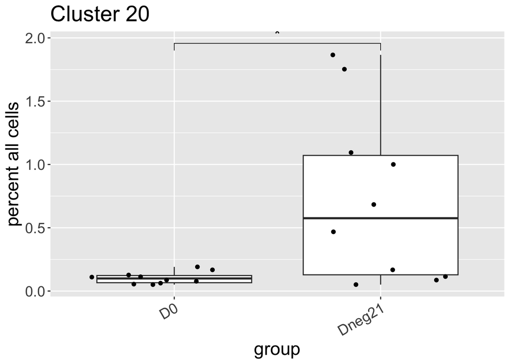

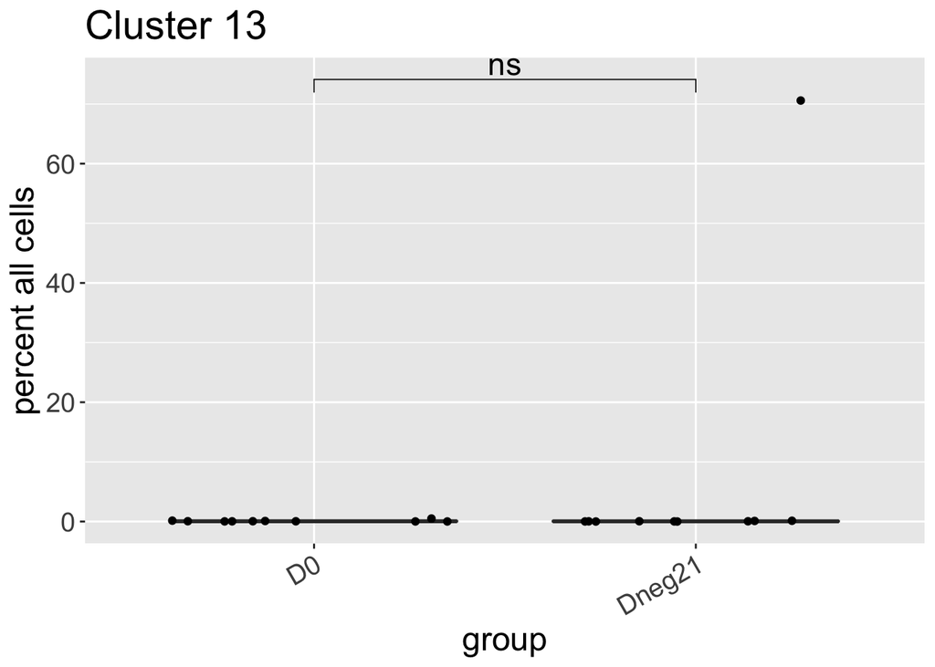

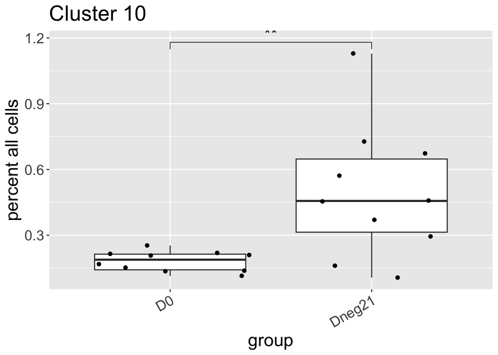

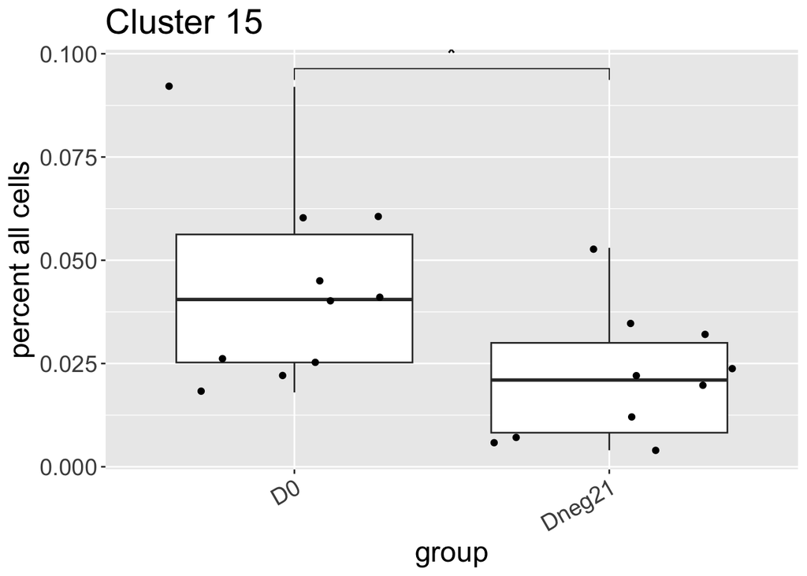

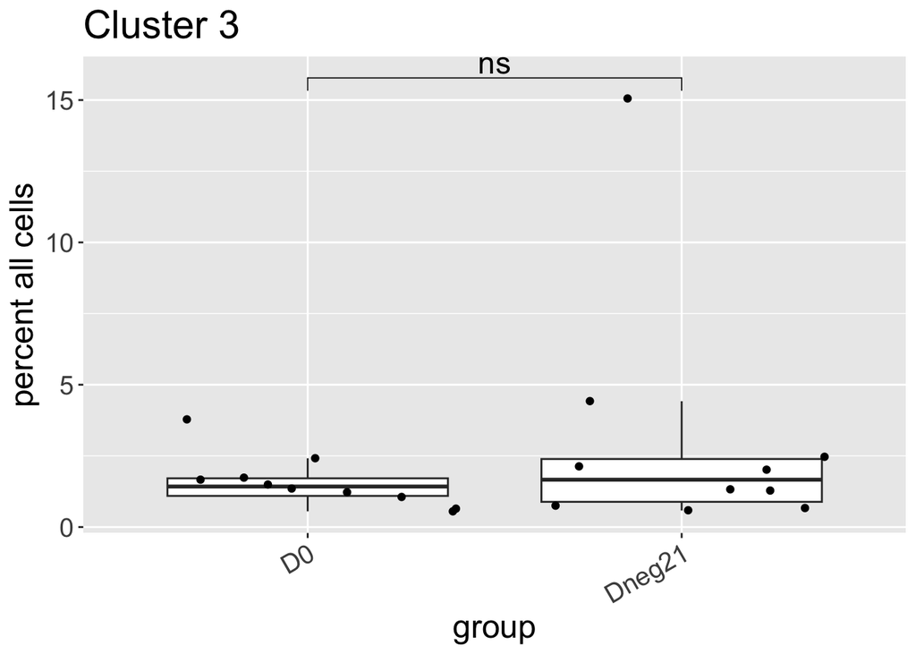

```r
cluster_id <- edger_table[1:5,]$cluster_id
comp_conds <- unique(md$group_id)
control_cond <- "D0" # Polysaccharide vaccine

PlotWrapper(
    clusters = cluster_id,
    Mat = d_freqs,
    to_save = FALSE,
    Comp_conds = comp_conds,
    Control_cond = control_cond,
    md = md
)
```

## Dimension reduction

Ok, the next thing we’re going to do is dimension reduction. With this, you can get a feel for how many cell subsets your data might have and how big each subset is. [Don’t read into it any more than that](https://tjburns08.github.io/tjb_dimr_talk.pdf).

We are going to use UMAP, as we did in the one fcs file example. It is relatively simple to run. Here is how you do it with the data, in its current format.

```r
library(tidyverse)
library(umap)

# Subsample the data and filter by surface markers
dimr_sample <- 10000
d_sub <- d_se[sample(nrow(d_se@elementMetadata), dimr_sample),]
surface <- d_se@colData$marker_name[d_se@colData$marker_class == "type"]

# Get the map in tibble form
dimr <- umap::umap(d = d_sub@assays@data$exprs[,surface])$layout %>% as_tibble()
names(dimr) <- c("umap1", "umap2")
```

Now, we use a dimension reduction visualization function to visualize the map and color it by what we want to see.

```r
#' @title Visualize dimension reduction plots
#' @description Plot dimension reduction map of interest colored by dimension
#' reduction comparison object of interest, with a blue to red color gradient.
#' Color palette is an attempt at the Cytobank rainbow palette.
#' @param cells Tibble of cells by features that the dimr was computed from
#' @param dimr Tibble of dimension reduction axis 1 and axis 2
#' @param marker vector of values for a particular marker
#' @param lim_min Minimum value to be colored
#' @param lim_max Maximum value to be colored
#' @return ggplot2 object
PlotViz <- function(cells, dimr, marker, lim_min = NULL, lim_max = NULL) {

    p <- qplot(x = dimr[[1]],
               y = dimr[[2]],
               color = cells[[marker]],
               xlab = names(dimr[1]),
               ylab = names(dimr[2])) +
        theme(legend.title = element_blank()) +
        geom_point(shape = ".") +
        ggtitle(marker)

    if(is.factor(cells[[marker]])) {
        return(p)
    }

    if(!is.null(lim_min)) {
        p <- p + scale_color_gradientn(colors = c("blue", "cyan", "springgreen", "yellow", "orange", "red", "red4"), limits = c(lim_min, lim_max))
    } else {
        p <- p + scale_color_gradientn(colors = c("blue", "cyan", "springgreen", "yellow", "orange", "red", "red4"))
    }

    return(p)
}
```

Now let’s visualize a few markers as before.

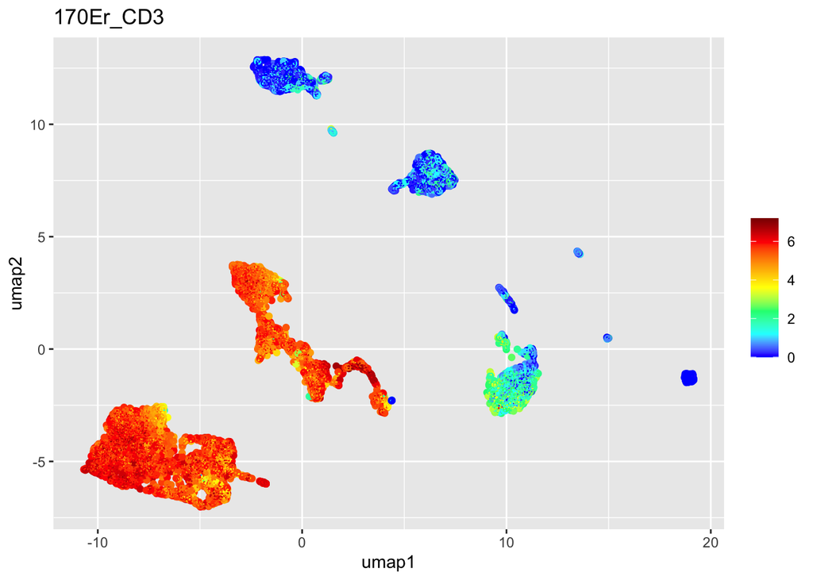

```r
# Get the data out of the SummarizedExperiment class
out_cells <- as_tibble(d_sub@assays@data$exprs)
PlotViz(cells = out_cells, dimr = dimr, marker = '170Er_CD3')
```

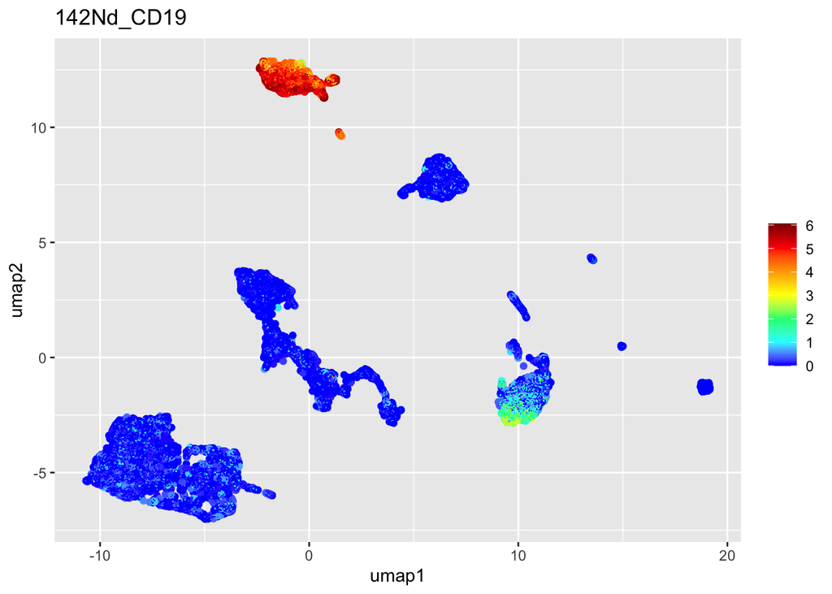

```r
PlotViz(cells = out_cells, dimr = dimr, marker = '142Nd_CD19')
```

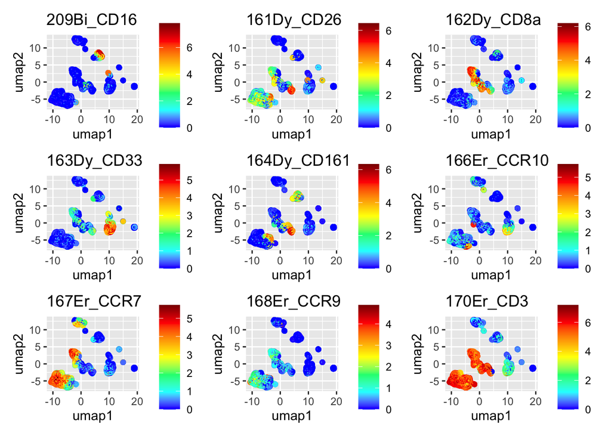

```r
library(patchwork)

p_list <- lapply(names(out_cells[,surface][1:9]), function(i) {
    PlotViz(cells = out_cells, dimr = dimr, marker = i)
})

(p_list[[1]] + p_list[[2]] + p_list[[3]]) / (p_list[[4]] + p_list[[5]] + p_list[[6]]) / (p_list[[7]] + p_list[[8]] + p_list[[9]])
```

Ok, now let’s do some plotting of our metadata. To do that, we need the metadata label cell by cell. Here is what that looks like.

```r
md_percell <- d_sub@elementMetadata
md_percell
```

```
## DataFrame with 10000 rows and 10 columns
##                                                 file_name    plate patient_id
##                                                  <factor> <factor>   <factor>
## 1     Plate19_8016_TT_D0_TD_Live Intact Singlets.fcs       Plate19       8016
## 2     Plate18_8763_TT_D0_nTD_Live Intact Singlets.fcs      Plate18       8763
## 3     Plate16_8733_TT_Dneg21_nTD_Live Intact Singlets.fcs  Plate16       8733
## 4     Plate13_8520_TT_D0_nTD_Live Intact Singlets.fcs      Plate13       8520
## 5     Plate12_8218_TT_D0_TD_Live Intact Singlets.fcs       Plate12       8218
## ...                                                   ...      ...        ...
## 9996  Plate11_8842_TT_Dneg21_nTD_Live Intact Singlets.fcs  Plate11       8842
## 9997  Plate16_8733_TT_D0_nTD_Live Intact Singlets.fcs      Plate16       8733
## 9998  Plate13_8520_TT_Dneg21_nTD_Live Intact Singlets.fcs  Plate13       8520
## 9999  Plate15_8144_TT_D0_nTD_Live Intact Singlets.fcs      Plate15       8144
## 10000 Plate12_8218_TT_Dneg21_TD_Live Intact Singlets.fcs   Plate12       8218
##        vaccine group_id diagnosis            gating_status sample_id read_error
```

[output cut: 25 more lines]

We’ll start with that. Note that the “group_id” column, which is the “day” post vaccine is messed up. The three timepoints are D0, D7, and D28. But for whatever reason, we have D0, Dneg21, and Dneg28. I think the neg is explained as a possible automated change from D-28 to Dneg28. But Dneg21 doesn’t make sense to me, as this should be D7. This is part of a much bigger problem of data from otherwise good publicaitons being either obfuscated or completely absent. I bent over backwards to make my data transparent only to encounter the fury of reviewer 3 nonetheless.

Anyway, let’s look a at cluster ID and group_id.

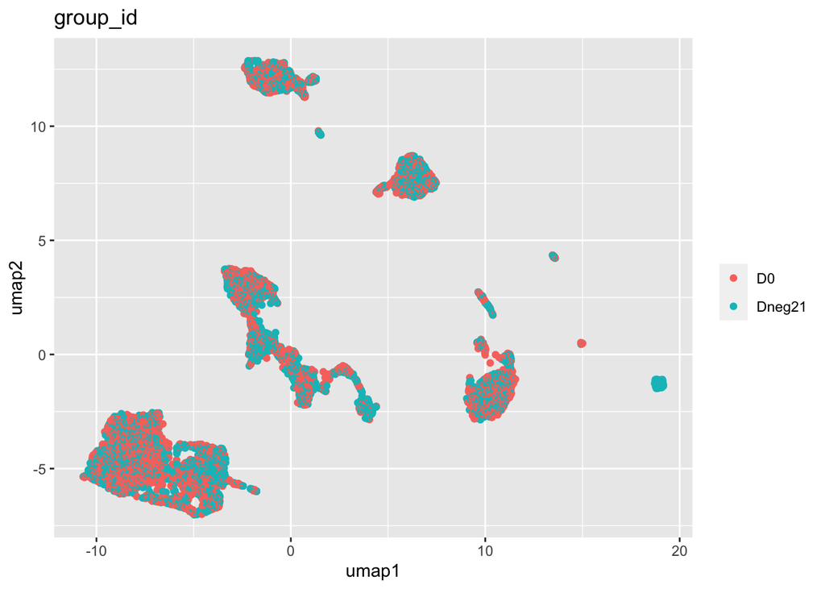

```r
out_cells <- bind_cols(out_cells, as_tibble(md_percell))
PlotViz(cells = out_cells, dimr = dimr, marker = "group_id")
```

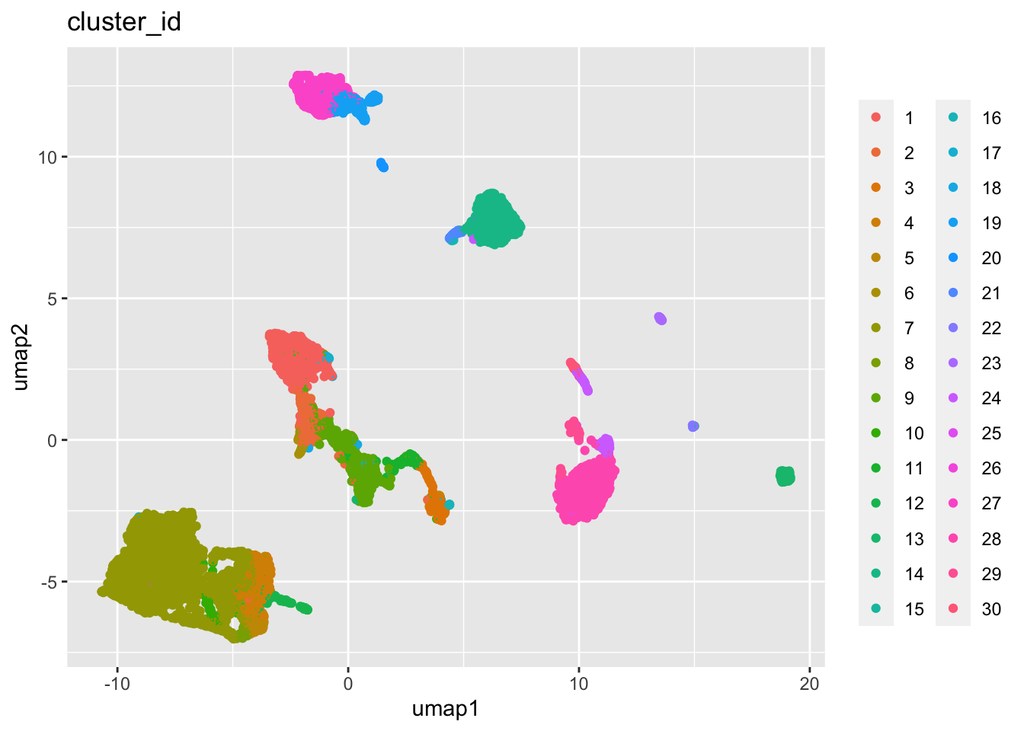

```r
PlotViz(cells = out_cells, dimr = dimr, marker = "cluster_id")
```

The group ID appears to be well-mixed, with some exceptions. But if you really wanted to examine this, you would simply look at every cell’s k-nearest neighbors in terms of the percentage of the two groups. You can read more about it in my pre-print [here](https://www.biorxiv.org/content/10.1101/337485v1). Look at figure 2.

What if we want to visualize the map by p-values? Rather than relying on any package to have the element metadata served up for us, we need a way assign the per-cluster statistics to each cell. Then, we would have to take the negative log10 of the p values (0.01 -> 2, 0.001 -> 3, etc) so they can fit on a color scheme that would otherwise be smashed to zero.

We will do that now. We’re going to iterate through the cluster ID column of our data, and for each cluster, we’re going to do a lookup of the corresponding p-values of interest. We’ll use the diffcyt p-values for now, but you can switch out the following block of code with whatever table of p-values you please.

To refresh your member, here’s the EdgeR table that was previously calculated. It has p-values for every cluster.

```r
edger_table[1:10,]
```

```
## # A tibble: 10 × 3
##    cluster_id      p_val     p_adj
##    <fct>           <dbl>     <dbl>
##  1 20         0.00000138 0.0000414
##  2 13         0.0000395  0.000593
##  3 10         0.000289   0.00289
##  4 15         0.0310     0.233
##  5 3          0.0807     0.371
##  6 4          0.0940     0.371
##  7 23         0.0991     0.371
##  8 26         0.0947     0.371
##  9 22         0.123      0.409
## 10 16         0.208      0.624
```

```r
neg_log10_p_adj <- lapply(out_cells$cluster_id, function(i) {
    result <- dplyr::filter(edger_table, cluster_id == i)$p_adj
}) %>% unlist()

neg_log10_p_adj <- -log10(neg_log10_p_adj)
```

Great. Now we’re going to color the map by the p-value itself so you can see what regions of the map are statistically significant.

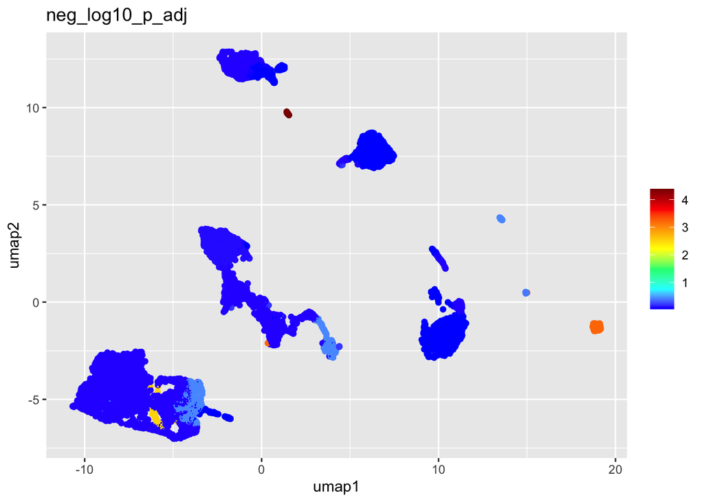

```r
out_cells$neg_log10_p_adj <- neg_log10_p_adj
PlotViz(cells = out_cells, dimr = dimr, marker = "neg_log10_p_adj")
```

Ok, and that will do it for now. I hope this helps you in putting together a CyTOF pipeline for your data. Additional tools and visualizations are available with CyTOF workflow, [here](https://www.bioconductor.org/packages/release/workflows/vignettes/cytofWorkflow/inst/doc/cytofWorkflow.html). There are other rabbit holes we can go down around QC, but that will be for another time.